# SOS Biologiacal data visualisation: CORTISOL

#load libraries: library(dplyr) library(tidyverse) library(ggplot2) library(“data.table”) library(stringr) library(“plyr”) library(ggpubr) library(DescTools) library(MESS)

First, we import the SOS_hormones_cleaned.csv file and remove participants who do not have Cortisol data at all 4 time points.

```r
#import cleaned bioloigcal dataset:
setwd("~/Documents/8_Byrne_work/SOS_Bioloigical_data_cleaned")
SOS_hormones_cleaned <- read.csv('SOS_hormones_cleaned.csv')
SOS_hormones_cleaned$SampleID <- as.character(SOS_hormones_cleaned$SampleID)

#Create variable specfic to Cortisol:
SOS_Cortisol <- SOS_hormones_cleaned[,c("SampleID", "Time","Cortisol_ug_dL", "Cortisol_log", "Cortisol_log")]

#Remove participants who do not have all 3 timepoints:
SOS_Cortisol_T1 = SOS_Cortisol %>% filter(Time == "1")
SOS_Cortisol_T2 = SOS_Cortisol %>% filter(Time == "2")
SOS_Cortisol_T3 = SOS_Cortisol %>% filter(Time == "3")
SOS_Cortisol_T4 = SOS_Cortisol %>% filter(Time == "4")

Merge1 <-merge(SOS_Cortisol_T1, SOS_Cortisol_T2, by = "SampleID", all = FALSE, all.x = TRUE)
Merge2 <-merge(Merge1, SOS_Cortisol_T3, by = "SampleID", all = FALSE, all.x = TRUE)
SOS_Cortisol_reshaped <-merge(Merge2, SOS_Cortisol_T4, by = "SampleID", all = FALSE, all.x = TRUE)
```

```
column names ‘Time.x’, ‘Cortisol_ug_dL.x’, ‘Cortisol_log.x’, ‘Cortisol_log.1.x’, ‘Time.y’, ‘Cortisol_ug_dL.y’, ‘Cortisol_log.y’, ‘Cortisol_log.1.y’ are duplicated in the result
```

```r
SOS_Cortisol_all_timepoints <- na.omit(SOS_Cortisol_reshaped)

#Merge to now include only the people who have all 4 timepoints:
SOS_Cortisol_final <- merge(SOS_Cortisol, SOS_Cortisol_all_timepoints, by = "SampleID", all = FALSE)
SOS_Cortisol_final <- SOS_Cortisol_final[1:5]
SOS_Cortisol_final <- (SOS_Cortisol_final %>% arrange(SampleID,Time))

total <- unique(SOS_Cortisol$SampleID)
total_keep <- unique(SOS_Cortisol_final$SampleID)
perc_all_timepoints <- ((length(total_keep))/(length(total)))*100

perc_all_timepoints
```

```
[1] 80.76923
```

Plot each participants response (Cortisol_log) over time:

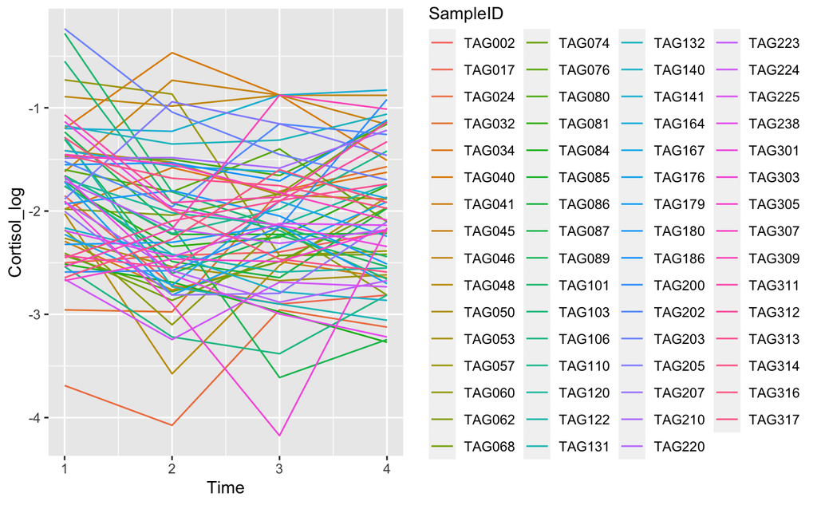

```r
#Clear variables no longer needed:
rm(SOS_Cortisol_T1, SOS_Cortisol_T2,SOS_Cortisol_T3,SOS_Cortisol_T4, Merge1, Merge2, SOS_Cortisol_reshaped, SOS_Cortisol_all_timepoints, SOS_Cortisol)

All_participants_plot <- ggplot(SOS_Cortisol_final, aes(x = Time, y = Cortisol_log, group = SampleID, colour = SampleID)) +
                          geom_line()
All_participants_plot
```

```r
#Clear variables we no longer need:
rm(All_participants_plot)

# Identify where the maximum value is (T1-T4) and add as a variable to dataframe
PeakTime <- list()
PeakTime_id <- list()
Responders <- list()

for (i in unique(SOS_Cortisol_final$SampleID)) {
    idx <- which(SOS_Cortisol_final$SampleID==i, arr.ind=TRUE)
    #Get participants peak timepoint
    PeakTime[i] <- which.max(SOS_Cortisol_final$Cortisol_log[idx])
    #Get SampleID
    PeakTime_id[i] <- i
    #Using T1 > T2,T3,T4 as exclusion criteria, split group into "Responders" and "Not Responders"
      if (PeakTime[i] == "1"){
      Responders[i] <- "0"
      } else {
      Responders[i] <- "1"
      }
    }

PeakTime <- data.frame(PeakTime)
PeakTime <- t(PeakTime)
PeakTime <- data.frame(PeakTime)

PeakTime_id <- data.frame(PeakTime_id)
PeakTime_id <- t(PeakTime_id)
PeakTime_id <- data.frame(PeakTime_id)

Responders <- data.frame(Responders)
Responders <- t(Responders)
Responders <- data.frame(Responders)


Peak_time_all <- cbind(PeakTime, PeakTime_id, Responders)
#Clear variables no longer needed:
rm(PeakTime, PeakTime_id)

names(Peak_time_all)[1]<- "PeakTime"
names(Peak_time_all)[2]<- "SampleID"
names(Peak_time_all)[3]<- "Responders"

SOS_Cortisol_final <-merge(SOS_Cortisol_final, Peak_time_all, by = "SampleID", all = TRUE)
rm(Peak_time_all)
SOS_Cortisol_final$PeakTime <- as.factor(SOS_Cortisol_final$PeakTime)
```

We have split the data according to where the participant’s maximum Cortisol response occured; at time point 1, 2, 3 or 4. We can then plot the change over time, depending on the group variable “Peak Time”:

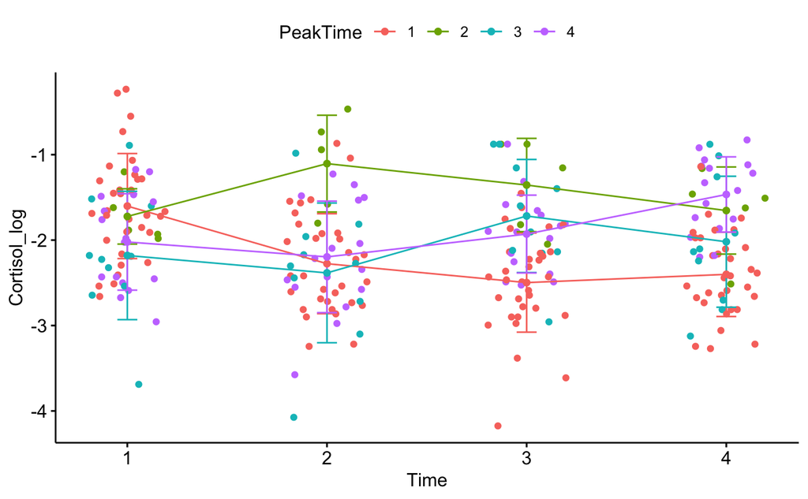

```r
Overall <- ggline(SOS_Cortisol_final, "Time", "Cortisol_log",
           group = "PeakTime",
           add = c("mean_sd", "jitter"),
           color = "PeakTime")
Overall
```

```r
summary(SOS_Cortisol_final)
```

```
   SampleID              Time      Cortisol_ug_dL     Cortisol_log     Cortisol_log.1    PeakTime
 Length:252         Min.   :1.00   Min.   :0.01100   Min.   :-4.1743   Min.   :-4.1743   1:128
 Class :character   1st Qu.:1.75   1st Qu.:0.07975   1st Qu.:-2.5289   1st Qu.:-2.5289   2: 20
 Mode  :character   Median :2.50   Median :0.12350   Median :-2.0915   Median :-2.0915   3: 40
                    Mean   :2.50   Mean   :0.16466   Mean   :-2.0431   Mean   :-2.0431   4: 64
                    3rd Qu.:3.25   3rd Qu.:0.20650   3rd Qu.:-1.5775   3rd Qu.:-1.5775
                    Max.   :4.00   Max.   :0.79100   Max.   :-0.2345   Max.   :-0.2345
 Responders
 0:128
 1:124
```

The number of subjects per “Peak Time” group:

```r
(summary(SOS_Cortisol_final$PeakTime)/4)
```

```
 1  2  3  4
32  5 10 16
```

```r
#Clear variable we no longer need:
rm(Overall)

#Divide participants by when their cortisol peak occured:
PeakTime1 <- SOS_Cortisol_final %>% filter(PeakTime == "1")
PeakTime2 <- SOS_Cortisol_final %>% filter(PeakTime == "2")
PeakTime3 <- SOS_Cortisol_final %>% filter(PeakTime == "3")
PeakTime4 <- SOS_Cortisol_final %>% filter(PeakTime == "4")
```

Now for more detail, within each “Peak time” group, we can see how individual subjects reacted:

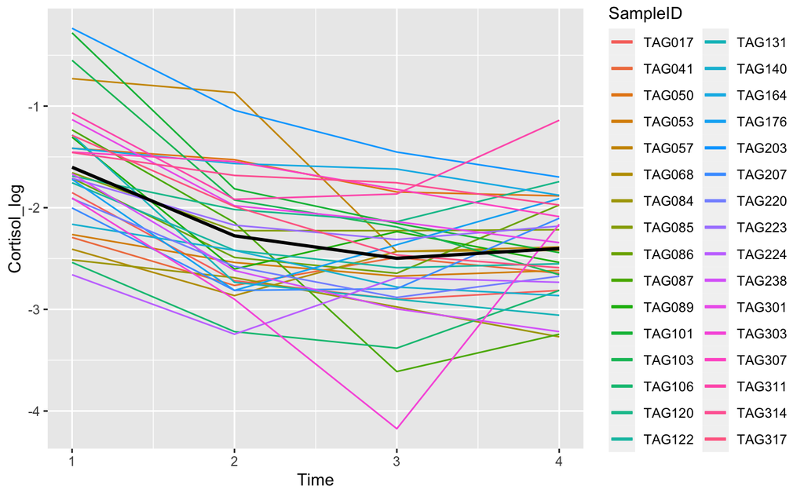

```r
PT1 <- ggplot(data = PeakTime1,aes(x = Time, y = Cortisol_log, group = SampleID, colour = SampleID)) +
       geom_line()+
       stat_summary(aes(group = 1), geom = "line", fun = mean, size = 1)

PT1
```

Descriptive stats of subjects whose response peaks at Timepoint 1

```r
summary(PeakTime1)
```

```
   SampleID              Time      Cortisol_ug_dL    Cortisol_log     Cortisol_log.1    PeakTime
 Length:128         Min.   :1.00   Min.   :0.0110   Min.   :-4.1743   Min.   :-4.1743   1:128
 Class :character   1st Qu.:1.75   1st Qu.:0.0700   1st Qu.:-2.6593   1st Qu.:-2.6593   2:  0
 Mode  :character   Median :2.50   Median :0.1080   Median :-2.2256   Median :-2.2256   3:  0
                    Mean   :2.50   Mean   :0.1414   Mean   :-2.1941   Mean   :-2.1941   4:  0
                    3rd Qu.:3.25   3rd Qu.:0.1730   3rd Qu.:-1.7545   3rd Qu.:-1.7545
                    Max.   :4.00   Max.   :0.7910   Max.   :-0.2345   Max.   :-0.2345
 Responders
 0:128
 1:  0
```

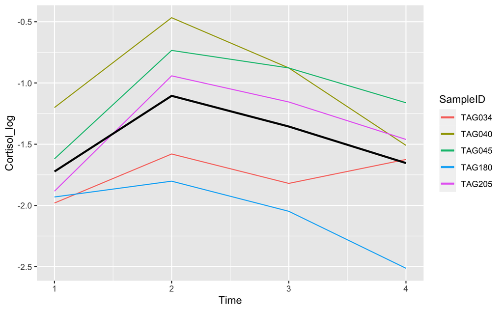

```r
PT2 <- ggplot(data = PeakTime2,aes(x = Time, y = Cortisol_log, group = SampleID, colour = SampleID)) +
      geom_line()+
      stat_summary(aes(group = 1), geom = "line", fun = mean, size = 1)
PT2
```

Descriptive stats of subjects whose response peaks at Timepoint 2

```r
summary(PeakTime2)
```

```
   SampleID              Time      Cortisol_ug_dL    Cortisol_log     Cortisol_log.1    PeakTime
 Length:20          Min.   :1.00   Min.   :0.0810   Min.   :-2.5133   Min.   :-2.5133   1: 0
 Class :character   1st Qu.:1.75   1st Qu.:0.1595   1st Qu.:-1.8361   1st Qu.:-1.8361   2:20
 Mode  :character   Median :2.50   Median :0.2135   Median :-1.5447   Median :-1.5447   3: 0
                    Mean   :2.50   Mean   :0.2747   Mean   :-1.4594   Mean   :-1.4594   4: 0
                    3rd Qu.:3.25   3rd Qu.:0.3337   3rd Qu.:-1.1018   3rd Qu.:-1.1018
                    Max.   :4.00   Max.   :0.6270   Max.   :-0.4668   Max.   :-0.4668
 Responders
 0: 0
 1:20
```

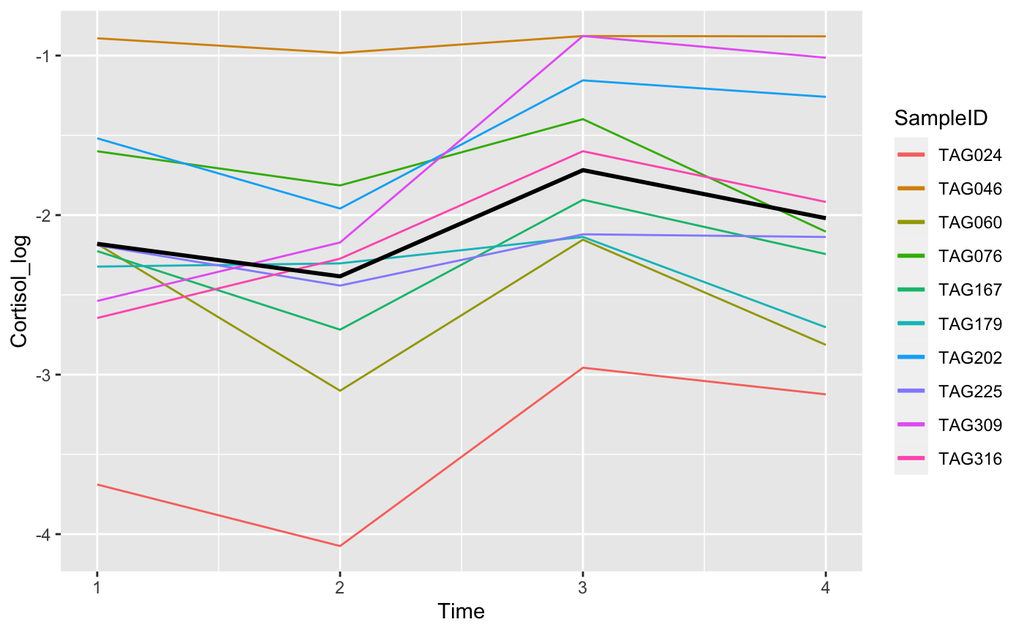

```r
PT3 <- ggplot(data = PeakTime3,aes(x = Time, y = Cortisol_log, group = SampleID, colour = SampleID)) +
      geom_line()+
     stat_summary(aes(group = 1), geom = "line", fun = mean, size = 1)
PT3
```

Descriptive stats of subjects whose response peaks at Timepoint 3

```r
summary(PeakTime3)
```

```
   SampleID              Time      Cortisol_ug_dL    Cortisol_log     Cortisol_log.1    PeakTime
 Length:40          Min.   :1.00   Min.   :0.0170   Min.   :-4.0745   Min.   :-4.0745   1: 0
 Class :character   1st Qu.:1.75   1st Qu.:0.0850   1st Qu.:-2.4660   1st Qu.:-2.4660   2: 0
 Mode  :character   Median :2.50   Median :0.1170   Median :-2.1456   Median :-2.1456   3:40
                    Mean   :2.50   Mean   :0.1674   Mean   :-2.0753   Mean   :-2.0753   4: 0
                    3rd Qu.:3.25   3rd Qu.:0.2062   3rd Qu.:-1.5793   3rd Qu.:-1.5793
                    Max.   :4.00   Max.   :0.5270   Max.   :-0.8773   Max.   :-0.8773
 Responders
 0: 0
 1:40
```

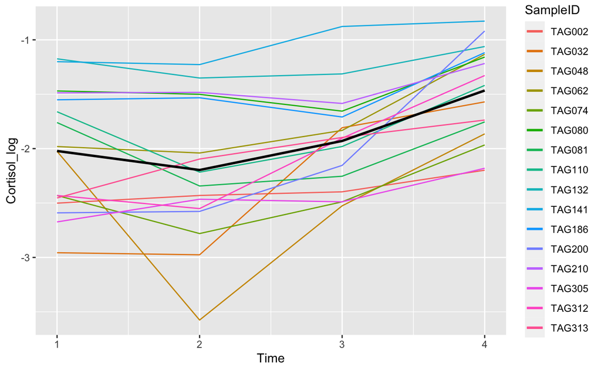

```r
PT4 <- ggplot(data = PeakTime4,aes(x = Time, y = Cortisol_log, group = SampleID, colour = SampleID)) +
        geom_line()+
        stat_summary(aes(group = 1), geom = "line", fun = mean, size = 1)
PT4
```

Descriptive stats of subjects whose response peaks at Timepoint 4

```r
summary(PeakTime4)
```

```
   SampleID              Time      Cortisol_ug_dL    Cortisol_log     Cortisol_log.1    PeakTime
 Length:64          Min.   :1.00   Min.   :0.0280   Min.   :-3.5756   Min.   :-3.5756   1: 0
 Class :character   1st Qu.:1.75   1st Qu.:0.0880   1st Qu.:-2.4304   1st Qu.:-2.4304   2: 0
 Mode  :character   Median :2.50   Median :0.1525   Median :-1.8807   Median :-1.8807   3: 0
                    Mean   :2.50   Mean   :0.1750   Mean   :-1.9033   Mean   :-1.9033   4:64
                    3rd Qu.:3.25   3rd Qu.:0.2278   3rd Qu.:-1.4795   3rd Qu.:-1.4795
                    Max.   :4.00   Max.   :0.4370   Max.   :-0.8278   Max.   :-0.8278
 Responders
 0: 0
 1:64
```

Some participants may be ‘non responders’, meaning they did not show a response to the task. If their peak response was at Timepoint 1, we have classified participants as ‘non responders’ (0). All other participants (who show peaks at Timepoints 2,3 or 4) are included as responders (1).

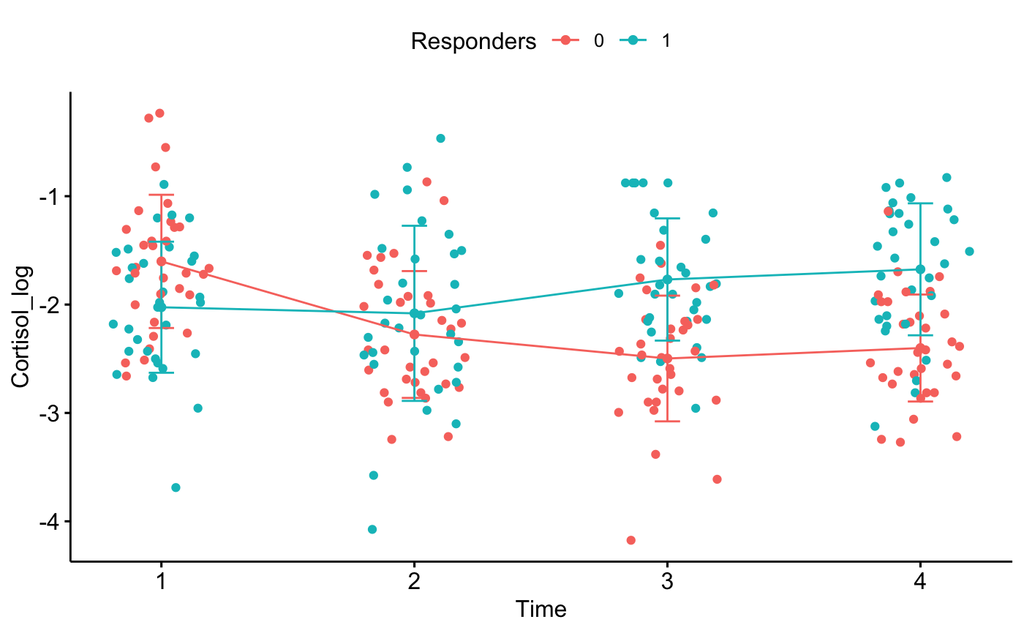

```r
#Clear variables no longer needed:
rm(PeakTime1, PT1,PeakTime2, PT2,PeakTime3, PT3, PeakTime4,PT4)

#Split group into "Responders" and "Not Responders"

RepondersvNoResponders_plot <-ggline(SOS_Cortisol_final, "Time", "Cortisol_log",
                               add = c("mean_sd", "jitter"),
                               color = "Responders")

RepondersvNoResponders_plot
```

The number of subjects Who are responders (1) and ‘non-responders’ (0)

```r
(summary(SOS_Cortisol_final$Responders)/4)
```

```
 0  1
32 31
```

```r
#Clear variable we no longer need:
rm(RepondersvNoResponders_plot)
```

We want to know whether responders (1) and ‘non-responders’ (0) showed a significantly different response at Timepoint 1:

```r
#Do a t-test to compare whether non-responders(0) had a higher T1 than responders(1)
Time_point_1 <- SOS_Cortisol_final[1:7]
Time_point_1 = Time_point_1 %>% filter(Time == "1")

compare_means(Cortisol_log ~ Responders, data = Time_point_1,
              method = "t.test")
```

| .y. | group1 | group2 | p | p.adj | p.format | p.signif | method |
| --- | --- | --- | --- | --- | --- | --- | --- |
| Cortisol_log | 0 | 1 | 0.007777374 | 0.0078 | 0.0078 | ** | T-test |

People show differing baseline levels of cortisol responding. We can calculate their relative change from baseline (Timepoint 1) at Timepoints 2,3 and 4.

```r
rm(i, idx)

#For each subject, normalise time points 2,3 and 4, to timepoint 1.
Normalised_values <- list()
Normalise_id <- list()

for (i in as.character(SOS_Cortisol_final$SampleID)) {
  idx <- which(SOS_Cortisol_final$SampleID==i, arr.ind=TRUE)
  SampleID_current <- i
  baseline <- SOS_Cortisol_final$Cortisol_log[idx[1]]
    for (t in 1:4){
    Normalised_values[idx[t]] <- (SOS_Cortisol_final$Cortisol_log[idx[t]] - baseline)
    Normalise_id[idx[t]] <- SampleID_current
    }
}

#Reformat lists into data.frames
Normalised_values <- data.frame(Normalised_values)
Normalised_values <- t(Normalised_values)
Normalised_values <- data.frame(Normalised_values)

Normalise_id <- data.frame(Normalise_id)
Normalise_id <- t(Normalise_id)
Normalise_id <- data.frame(Normalise_id)
#Merge two data.frames
Normalised_all <- cbind(Normalised_values, Normalise_id)

#Clear variables no longer needed:
rm(Normalised_values, Normalise_id)

#Rename columns for merge (SampleID, also helps for checking that the rows have matched appropriately)
names(Normalised_all)[1]<- "BL_Norm_Cortisol_log"
names(Normalised_all)[2]<- "SampleID"

#Merge with SOS_Cortisol_final and remove unecessary extra SampleID column:
SOS_Cortisol_final <- cbind(SOS_Cortisol_final, Normalised_all)
SOS_Cortisol_final <- SOS_Cortisol_final[1:8]

#Clear variables no longer needed:
rm(Normalised_all, baseline, i, idx, SampleID_current, t)
```

Plot of change over time, depending on the group variable “Peak Time”:

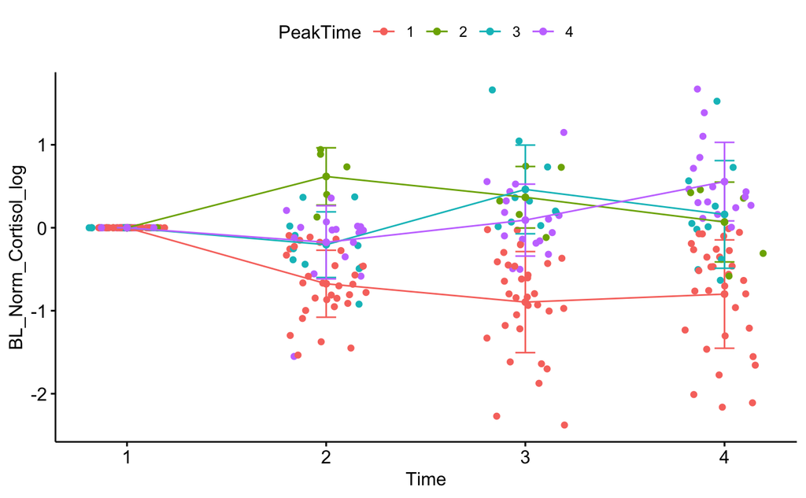

```r
Relative_to_baseline <- ggline(SOS_Cortisol_final, "Time", "BL_Norm_Cortisol_log",
           group = "PeakTime",
           add = c("mean_sd", "jitter"),
           color = "PeakTime")
Relative_to_baseline
```

Plot of change over time, depending on whether responders (1) and ‘non-responders’ (0)

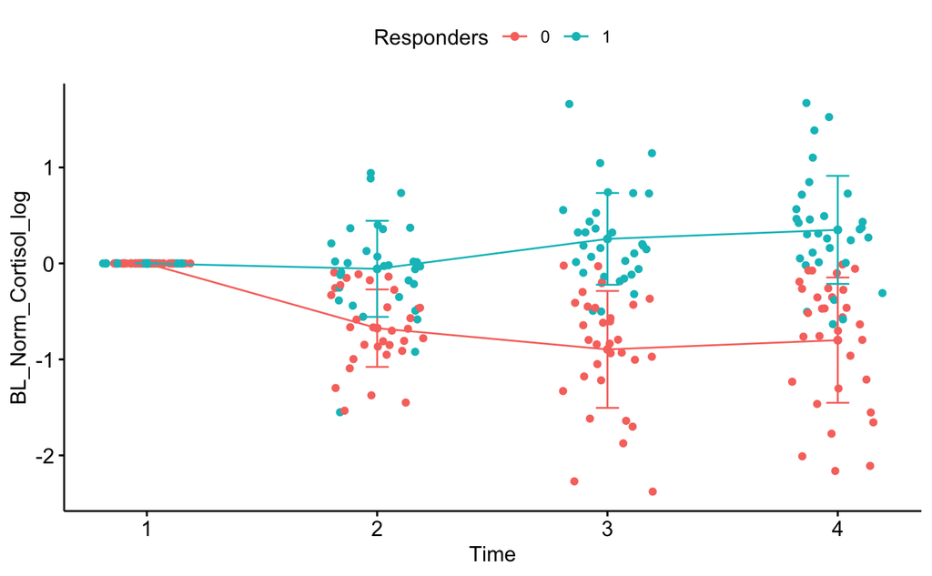

```r
Relative_to_baseline_resp <- ggline(SOS_Cortisol_final, "Time", "BL_Norm_Cortisol_log",
           group = "Responders",
           size = 0.5,
           add = c("mean_sd", "jitter"),
           color = "Responders")
Relative_to_baseline_resp
```

We want to know whether there are significant increases over time (relative to baseline) for responders (1):

```r
rm(Relative_to_baseline, Relative_to_baseline_resp)

#Test effect of time on response
Responders <- SOS_Cortisol_final[1:8]
Responders = Responders %>% filter(Responders == 1)

compare_means(BL_Norm_Cortisol_log ~ Time, data = Responders,
              method = "anova")
```

| .y. | p | p.adj | p.format | p.signif | method |
| --- | --- | --- | --- | --- | --- |
| BL_Norm_Cortisol_log | 0.0007601074 | 0.00076 | 0.00076 | *** | Anova |

```r
NA
```

```r
#Follow up repeated measures t-tests
compare_means(BL_Norm_Cortisol_log ~ Time, data = Responders, paired = TRUE,
              method = "t.test")
```

| .y. | group1 | group2 | p | p.adj | p.format | p.signif | method |
| --- | --- | --- | --- | --- | --- | --- | --- |
| BL_Norm_Cortisol_log | 1 | 2 | 0.5352742319 | 0.5600 | 0.53527 | ns | T-test |
| BL_Norm_Cortisol_log | 1 | 3 | 0.0056603163 | 0.0170 | 0.00566 | ** | T-test |
| BL_Norm_Cortisol_log | 1 | 4 | 0.0016428332 | 0.0082 | 0.00164 | ** | T-test |
| BL_Norm_Cortisol_log | 2 | 3 | 0.0009245097 | 0.0055 | 0.00092 | *** | T-test |
| BL_Norm_Cortisol_log | 2 | 4 | 0.0017123601 | 0.0082 | 0.00171 | ** | T-test |
| BL_Norm_Cortisol_log | 3 | 4 | 0.2780699377 | 0.5600 | 0.27807 | ns | T-test |

```r
#Calculate the area under the curve for each responder:
AUC_list <- list()
AUC_id <- list()

for (i in unique(SOS_Cortisol_final$SampleID)) {
    idx <- which(SOS_Cortisol_final$SampleID==i, arr.ind=TRUE)
    #Get participants AUC for T1-4:
    AUC_list[i] <- auc(
                SOS_Cortisol_final$Time[idx],
                SOS_Cortisol_final$BL_Norm_Cortisol_log[idx],
                from = min(1, na.rm = TRUE),
                to = max(4, na.rm = TRUE),
                type = c("spline"),
                absolutearea = FALSE,
                subdivisions = 100
                )
    #Get SampleID
    AUC_id[i] <- i
}
#Reformat lists into data.frames
AUC_list <- data.frame(AUC_list)
AUC_list <- t(AUC_list)
AUC_list <- data.frame(AUC_list)

AUC_id <- data.frame(AUC_id)
AUC_id <- t(AUC_id)
AUC_id <- data.frame(AUC_id)

#Merge two data.frames
AUC_all <- cbind(AUC_list, AUC_id)

#Clear variables no longer needed:
rm(AUC_list, AUC_id)

#Rename columns for merge (SampleID, also helps for checking that the rows have matched appropriately)
names(AUC_all)[1]<- "AUC_BL_Norm_Cortisol_log"
names(AUC_all)[2]<- "SampleID"

#Merge with SOS_Cortisol_final and remove unecessary extra SampleID column:
SOS_Cortisol_final <-merge(SOS_Cortisol_final, AUC_all, by = "SampleID", all = TRUE)

#Clear variables no longer needed:
rm(i, idx, AUC_all)

#Update Responders dataframe to include AUC
Responders <- SOS_Cortisol_final[1:9]
Responders = Responders %>% filter(Responders == 1)
```

Plot AUC values:

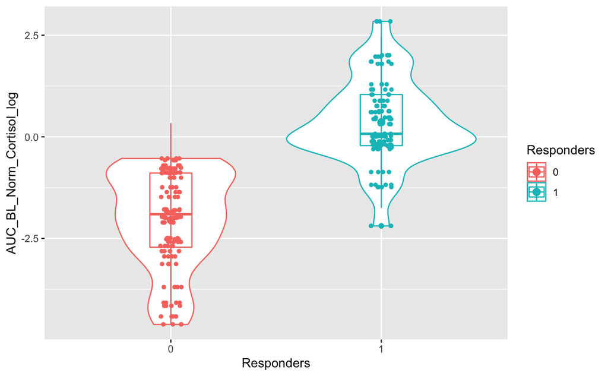

```r
#Plot AUC value for
AUC_plot <- ggplot(SOS_Cortisol_final, aes(Responders, AUC_BL_Norm_Cortisol_log, colour=Responders)) +
    geom_violin() +
    geom_boxplot(width=0.2, position = "dodge2") +
    stat_summary(fun.data=mean_sdl,
                 geom="pointrange") +
    geom_jitter(shape=16, position=position_jitter(0.05))

AUC_plot
```

```r
rm(AUC_plot)
```

We can see that the greatest change in Cortisol level occurs between T2 and T3. We are therefore interested to quantify the magnitude of this change per participant. If participant’s change is +ve (meaning an increase from T2 –> T3) = 1. If participant’s change is -ve (meaning a decrease from T2 –> T3) = 0:

```r
T2T3_list <- list()
T2T3_id <- list()
T2T3_direction <- list()

for (i in as.character(SOS_Cortisol_final$SampleID)){
    idx <- which(SOS_Cortisol_final$SampleID==i, arr.ind=TRUE)
    T2T3_id[i] <-i
    T2T3_list[i] <-(SOS_Cortisol_final$Cortisol_log[idx[3]] - SOS_Cortisol_final$Cortisol_log[idx[2]])
     if (T2T3_list[i] > "0"){
      T2T3_direction[i] <- "1"
      } else {
      T2T3_direction[i] <- "0"
      }
    }

#Reformat lists into data.frames
T2T3_list <- data.frame(T2T3_list)
T2T3_list <- t(T2T3_list)
T2T3_list <- data.frame(T2T3_list)

T2T3_id <- data.frame(T2T3_id)
T2T3_id <- t(T2T3_id)
T2T3_id <- data.frame(T2T3_id)

T2T3_direction <- data.frame(T2T3_direction)
T2T3_direction <- t(T2T3_direction)
T2T3_direction <- data.frame(T2T3_direction)

#Merge two data.frames
T2T3_all <- cbind(T2T3_list, T2T3_id, T2T3_direction)

#Clear variables no longer needed:
rm(T2T3_list, T2T3_id, T2T3_direction)

#Rename columns for merge (SampleID, also helps for checking that the rows have matched appropriately)
names(T2T3_all)[1]<- "Change_T2_T3"
names(T2T3_all)[2]<- "SampleID"
names(T2T3_all)[3]<- "Change_T2_T3_Direction"

#Merge with SOS_Cortisol_final and remove unecessary extra SampleID column:
SOS_Cortisol_final <-merge(SOS_Cortisol_final, T2T3_all, by = "SampleID", all = TRUE)
rm(T2T3_all)

(summary(SOS_Cortisol_final$Change_T2_T3_Direction)/4)
```

```
 0  1
34 29
```

```r
SOS_Cortisol_final$Change_T2_T3_Direction <- as.factor(SOS_Cortisol_final$Change_T2_T3_Direction)
```

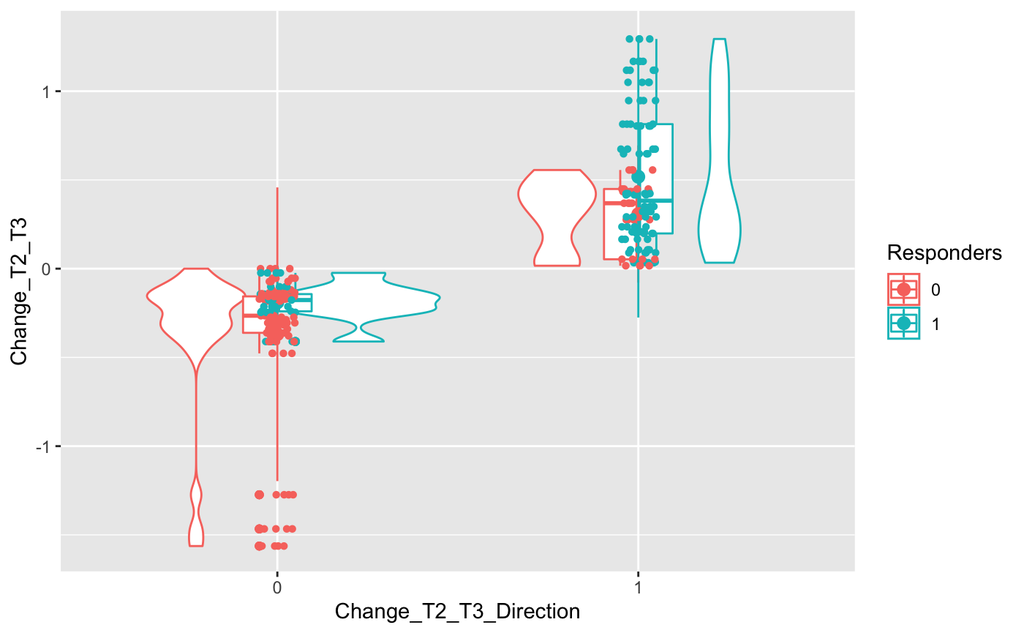

```r
ChangeT2T3 <- ggplot(SOS_Cortisol_final, aes(Change_T2_T3_Direction, Change_T2_T3, colour=Responders)) +
    geom_violin() +
    geom_boxplot(width=0.2, position = "dodge2") +
    stat_summary(fun.data=mean_sdl,
                 geom="pointrange") +
    geom_jitter(shape=16, position=position_jitter(0.05))

ChangeT2T3
```

How many people are responders who have a positive change:

```r
Resp_pos <- count(which(SOS_Cortisol_final$Responders == 1 & SOS_Cortisol_final$Change_T2_T3_Direction == 1))
(nrow(Resp_pos)/4)
```

```
[1] 22
```

How many people are responders who have a negative change:

```r
Resp_neg <- count(which(SOS_Cortisol_final$Responders == 1 & SOS_Cortisol_final$Change_T2_T3_Direction == 0))
(nrow(Resp_neg)/4)
```

```
[1] 9
```

How many people are non-responders who have a positive change:

```r
Non_resp_pos <- count(which(SOS_Cortisol_final$Responders == 0 & SOS_Cortisol_final$Change_T2_T3_Direction == 1))
(nrow(Non_resp_pos)/4)
```

```
[1] 7
```

How many people are non-responders who have a negative change:

```r
Non_resp_neg <- count(which(SOS_Cortisol_final$Responders == 0 & SOS_Cortisol_final$Change_T2_T3_Direction == 0))
(nrow(Non_resp_neg)/4)
```

```
[1] 25
```

```r
rm(Resp_pos, Resp_neg, Non_resp_pos, Non_resp_neg)
```

We are interested to see what the area under the curve looks like for people’s change between T2 and T3:

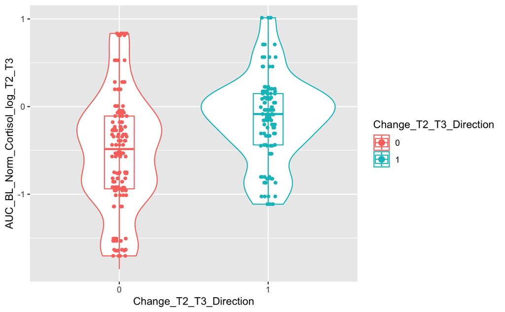

```r
#Calculate the area under the curve between T2 and T3:
AUC_list <- list()
AUC_id <- list()

for (i in unique(SOS_Cortisol_final$SampleID)) {
    idx <- which(SOS_Cortisol_final$SampleID==i, arr.ind=TRUE)
    #Get participants AUC for T1-4:
    AUC_list[i] <- auc(
                SOS_Cortisol_final$Time[idx],
                SOS_Cortisol_final$BL_Norm_Cortisol_log[idx],
                from = min(2, na.rm = TRUE),
                to = max(3, na.rm = TRUE),
                type = c("linear"),
                absolutearea = FALSE,
                subdivisions = 100
                )
    #Get SampleID
    AUC_id[i] <- i
}
#Reformat lists into data.frames
AUC_list <- data.frame(AUC_list)
AUC_list <- t(AUC_list)
AUC_list <- data.frame(AUC_list)

AUC_id <- data.frame(AUC_id)
AUC_id <- t(AUC_id)
AUC_id <- data.frame(AUC_id)

#Merge two data.frames
AUC_all <- cbind(AUC_list, AUC_id)

#Clear variables no longer needed:
rm(AUC_list, AUC_id)

#Rename columns for merge (SampleID, also helps for checking that the rows have matched appropriately)
names(AUC_all)[1]<- "AUC_BL_Norm_Cortisol_log_T2_T3"
names(AUC_all)[2]<- "SampleID"

#Merge with SOS_Cortisol_final and remove unecessary extra SampleID column:
SOS_Cortisol_final <-merge(SOS_Cortisol_final, AUC_all, by = "SampleID", all = TRUE)
rm(AUC_all)

AUC_plot <- ggplot(SOS_Cortisol_final, aes(Change_T2_T3_Direction, AUC_BL_Norm_Cortisol_log_T2_T3, colour=Change_T2_T3_Direction)) +
    geom_violin() +
    geom_boxplot(width=0.2, position = "dodge2") +
    stat_summary(fun.data=mean_sdl,
                 geom="pointrange") +
    geom_jitter(shape=16, position=position_jitter(0.05))
AUC_plot
```